# How to Use Rstudio with ESSENCE APIs

2019-03-14

### ESSENCE APIs

In this RMarkdown document, we will provide an overview of the ESSENCE APIs and how to access them through Rstudio. We will begin with a very brief explanation of application programming interfaces (APIs), then list what APIs are available in ESSENCE, and finally expose you to basic examples of R code and packages so that you can start using RStudio to access ESSENCE data, create your own R Markdown reports and Shiny applications, or do exploratory analyses not possible within ESSENCE.

An application programming interface, or API, is a structured and consistent way for one machine to exchange information with another machine. ESSENCE has APIs that allow you to programmatically access and further manipulate your data from outside the system. You may select the CSV format to export data, and in some instances JSON is also supported. More information about the APIs can be found in ESSENCE under “More,” then “User Guide,” and then [API Documentation](https://essence.syndromicsurveillance.org/nssp_essence/usersguide/api/documentation.jsp). You may write API URL syntax on your own after reading the documentation, or you can let ESSENCE create the API URL by clicking the “API URL” button on an ESSENCE page after completing a query.

At the time of this writing, ESSENCE offered six APIs:  
1) Time series data table,  
2) Time series png image,  
3) Table builder results,  
4) Data details (line level),  
5) Summary stats on the number of unique facilities or regions in your query results, and  
6) Alert list detection table.

### Rstudio

The first step is to create an R script or R Markdown file and load the necessary packages. By default, some packages might already be in your system library. But if not, you can install them yourself by clicking on the packages tab in the bottom-right quadrant of the RStudio interface and selecting the Install tab. Here are the package names and configuration statement you’ll need to get started:

```r
library(tidyverse)
library(knitr)
library(httr)
httr::set_config(config(ssl_verifypeer = 0L))
library(jsonlite)
library(keyring)
#key_set(service = "essence", username = "username")
```

To extract data from ESSENCE, you start by passing authentication information from your RStudio session to ESSENCE so that it knows what data you are allowed to see. *It is bad practice to explicitly include your username and password in your code*. Instead, we will use the keyring package to do this work for us. When you run this line of code (with your username entered in the username quotes)

> key_set(service = “essence”, username = “username”)

a pop-up will appear in RStudio where you will need to enter your password. (RStudio will store your password for the remainder of the session without rerunning that line of code.) Once you enter your password in the pop-up, be sure to “comment out” this line of code by adding a hash mark before it, like you see in the code chunk loading libraries above.

In each example that follows, you will see a common pattern emerge. First, define the URL as an object in your RStudio session; then pass your credentials and tell RStudio to “get” data from the URL; and, finally, format the last two to three lines of data into an R data frame for further analysis. By using this approach, R Markdown will give you an easily reproducible workflow where you integrate report text with code that reads in data, manipulates data as needed, and produces analyses and visualizations in such a way that can be handed off to colleagues without having to document manual actions (point/click, etc).

#### Time Series Data Table

In this example, we will show you how to pull a time series data table from ESSENCE into RStudio. (Note. All examples use the limited details data sources available in NSSP– ESSENCE.) In the code below, the first object created is the URL for the ESSENCE API endpoint of interest, which for this example is a national trend of the injury syndrome. The second object, API_response, gets data from the ESSENCE URL and then passes your credentials so that ESSENCE knows you are permitted to access these data. The next three objects are processing JSON-formatted data into an R data frame. The glimpse function (from dplyr) provides a quick sense of every variable in the data frame:

```r
url <- "https://essence.syndromicsurveillance.org/nssp_essence/api/timeSeries?endDate=7Dec2018&medicalGrouping=injury&percentParam=noPercent&geographySystem=hospitaldhhsregion&datasource=va_hospdreg&detector=probrepswitch&startDate=8Sep2018&timeResolution=daily&medicalGroupingSystem=essencesyndromes&userId=455&aqtTarget=TimeSeries"
api_response <- GET(url,
                    authenticate(key_list("essence")[1,2],
                                 key_get("essence",
                                 key_list("essence")[1,2])))
api_response_json <- content(api_response, as = "text")
api_data <- fromJSON(api_response_json)
api_data <- api_data$timeSeriesData

glimpse(api_data)
```

```
## Observations: 91
## Variables: 8
## $ date     <chr> "2018-09-08", "2018-09-09", "2018-09-10", "2018-09-11",…
## $ count    <dbl> 37454, 36157, 39936, 39307, 38875, 38312, 38848, 39133,…
## $ expected <chr> "39714.378", "39405.907", "42261.393", "40323.176", "39…
## $ levels   <chr> "0.997", "1", "0.997", "0.864", "0.658", "0.662", "0.54…
## $ colorID  <int> 1, 1, 1, 1, 1, 1, 1, 1, 1, 1, 1, 1, 1, 1, 1, 1, 1, 1, 1…
## $ color    <chr> "blue", "blue", "blue", "blue", "blue", "blue", "blue",…
## $ altText  <chr> "Data: Date: 08Sep18, Level: 0.997, Count: 37454, Expec…
## $ details  <chr> "/nssp_essence/api/dataDetails?medicalGrouping=injury&p…
```

#### Time Series Graph from ESSENCE

This example shows how to retrieve the ESSENCE graph itself instead of the underlying data for the graph, as shown previously. Here, we use the same national injury syndrome trend as before, but notice the URL now includes ..“api/timeSeries/graph?…”. You can add a title or axis labels by adding other parameters to the URL: “&graphTitle=Injury%20Syndrome&xAxisLabel=Date&yAxisLabel=Count”.

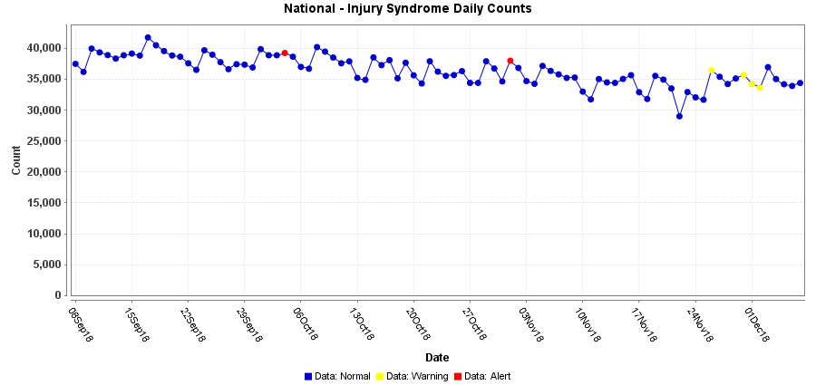

```r
url <- "https://essence.syndromicsurveillance.org/nssp_essence/api/timeSeries/graph?endDate=7Dec2018&medicalGrouping=injury&percentParam=noPercent&geographySystem=hospitaldhhsregion&datasource=va_hospdreg&detector=probrepswitch&startDate=8Sep2018&timeResolution=daily&medicalGroupingSystem=essencesyndromes&userId=455&aqtTarget=TimeSeries&graphTitle=National%20-%20Injury%20Syndrome%20Daily%20Counts&xAxisLabel=Date&yAxisLabel=Count"

api_response <- GET(url, authenticate(key_list("essence")[1,2],
                                 key_get("essence",
                                 key_list("essence")[1,2])),
                    write_disk("test.png", overwrite=TRUE))

knitr::include_graphics('test.png')
```

#### Example - CSV

```r
url <- "https://essence.syndromicsurveillance.org/nssp_essence/api/tableBuilder/csv?endDate=7Dec2018&medicalGrouping=injury&percentParam=noPercent&geographySystem=hospitaldhhsregion&datasource=va_hospdreg&detector=probrepswitch&startDate=8Sep2018&timeResolution=daily&medicalGroupingSystem=essencesyndromes&userId=455&aqtTarget=TableBuilder&rowFields=timeResolution&columnField=geographyhospitaldhhsregion"
api_response <- GET(url,
                    authenticate(key_list("essence")[1,2],
                                 key_get("essence",
                                 key_list("essence")[1,2])))
api_response_csv <- content(api_response, as = "text")
api_data <- read_csv(api_response_csv)

glimpse(api_data)
```

```
## Observations: 91
## Variables: 12
## $ timeResolution <date> 2018-09-08, 2018-09-09, 2018-09-10, 2018-09-11, …
## $ OTHER_REGION   <dbl> 0, 0, 0, 0, 0, 0, 0, 0, 0, 0, 0, 0, 0, 0, 0, 0, 0…
## $ `Region 1`     <dbl> 2723, 2506, 2609, 2514, 2554, 2517, 2692, 2801, 2…
## $ `Region 10`    <dbl> 1476, 1431, 1783, 1743, 1593, 1707, 1713, 1393, 1…
## $ `Region 2`     <dbl> 4231, 3867, 4173, 4102, 4333, 4124, 4303, 4554, 4…
## $ `Region 3`     <dbl> 4569, 4440, 4956, 4881, 4925, 4829, 4745, 4654, 4…
## $ `Region 4`     <dbl> 10019, 9635, 10630, 10410, 10058, 10054, 9696, 98…
## $ `Region 5`     <dbl> 6887, 6655, 7165, 7294, 7233, 7330, 7646, 7869, 7…
## $ `Region 6`     <dbl> 2545, 2611, 2751, 2639, 2730, 2764, 2668, 2705, 2…
## $ `Region 7`     <dbl> 1615, 1684, 1817, 1756, 1800, 1817, 1949, 1875, 1…
## $ `Region 8`     <dbl> 1374, 1262, 1559, 1436, 1367, 958, 1265, 1285, 12…
## $ `Region 9`     <dbl> 2015, 2066, 2493, 2532, 2282, 2212, 2171, 2187, 1…
```

You may have noticed that the table builder in the ESSENCE user interface is limited to creating tables of up to 30,000 cells. This is pretty large and should suffice in most cases. However, it may be useful to know that the table builder API does not impose a limit on the output table size. You will need to create the API instead of having ESSENCE create it for you using the “API URLs” button. To create your own API, start by familiarizing yourself with the structure of the [API](https://essence.syndromicsurveillance.org/nssp_essence/usersguide/api/documentation.jsp), and then add parameters that follow the structure. To help with this, look at some examples where ESSENCE has created API URLs for you using the available buttons.

#### Data Details (line level)

Sometimes you just need line-level data, and this example describes how to extract those data from ESSENCE. Obviously, this can create a very large data set quickly. As with any query with potential to create large data sets, first test the query on a small amount of data. Consider multiple calls of smaller time ranges then combine the separate data frames to create a final data set. This API gives you options. You can specify the variables to include and whether you want a data set with raw or reference values. Downloads with reference values take longer to stream into RStudio because ESSENCE has to create those reference values. You can reduce the file size by specifying only the variables you need and by adding additional parameters into the URL, like, for example, “&field=age&field=ChiefComplaintParsed.” Output formats for data details are CSV and JSON.

#### Example 1 - CSV

```r
url <- "https://essence.syndromicsurveillance.org/nssp_essence/api/dataDetails/csv?medicalGrouping=injury&geography=region%20i&percentParam=noPercent&geographySystem=hospitaldhhsregion&datasource=va_hospdreg&detector=probrepswitch&timeResolution=daily&medicalGroupingSystem=essencesyndromes&userId=455&aqtTarget=TimeSeries&startDate=27Nov18&endDate=27Nov18"
api_response <- GET(url,
                    authenticate(key_list("essence")[1,2],
                                 key_get("essence",
                                 key_list("essence")[1,2])))
api_data <- content(api_response, by = "csv/text") %>%
  read_csv()

glimpse(api_data)
```

```
## Observations: 2,268
## Variables: 13
## $ Date                <chr> "11/27/2018", "11/27/2018", "11/27/2018", "1…
## $ Category_flat       <chr> ";Injury;", ";Injury;", ";Injury;", ";Injury…
## $ SubCategory_flat    <chr> ";MotorVehicle;", ";Fall;", ";Fall;", ";Suff…
## $ Patient_Class       <chr> "E", "E", "E", "E", "E", "E", "E", "E", "E",…
## $ HospitalDHHSRegion  <chr> "Region I", "Region I", "Region I", "Region …
## $ dhhsregion          <chr> "Region I", "Region I", "Region I", "Region …
## $ AgeGroup            <chr> "Unknown", "00-04", "00-04", "00-04", "00-04…
## $ Sex                 <chr> "F", "F", "F", "M", "M", "F", "F", "F", "F",…
## $ DispositionCategory <chr> "DISCHARGED", "DISCHARGED", "none", "DISCHAR…
## $ HasBeenE            <dbl> 1, 1, 1, 1, 1, 1, 1, 1, 1, 1, 1, 1, 1, 1, 1,…
## $ HasBeenI            <dbl> 0, 0, 0, 0, 0, 0, 0, 0, 0, 0, 0, 0, 0, 0, 0,…
## $ HasBeenO            <dbl> 0, 0, 0, 0, 0, 0, 0, 0, 0, 0, 0, 0, 0, 0, 0,…
## $ DDAvailable         <dbl> 1, 1, 1, 1, 1, 1, 1, 1, 1, 1, 1, 1, 1, 1, 1,…
```

#### Example 2 - JSON

```r
url <- "https://essence.syndromicsurveillance.org/nssp_essence/api/dataDetails?endDate=27Nov2018&medicalGrouping=injury&percentParam=noPercent&geographySystem=hospitaldhhsregion&datasource=va_hospdreg&detector=probrepswitch&startDate=27Nov2018&timeResolution=daily&medicalGroupingSystem=essencesyndromes&userId=455&aqtTarget=DataDetails"
api_response <- GET(url,
                    authenticate(key_list("essence")[1,2],
                                 key_get("essence",
                                 key_list("essence")[1,2])))
api_response_json <- content(api_response, as = "text")
api_data <- fromJSON(api_response_json)
api_data <- api_data$dataDetails

glimpse(api_data)
```

```
## Observations: 35,374
## Variables: 13
## $ Date                <chr> "11/27/2018", "11/27/2018", "11/27/2018", "1…
## $ Category_flat       <chr> ";Injury;", ";Injury;", ";Injury;", ";Neuro;…
## $ SubCategory_flat    <chr> ";Fall;", ";Fall;", ";CutOrPierce;", ";Dizzi…
## $ Patient_Class       <chr> "E", "E", "E", "E", "E", "E", "E", "E", "E",…
## $ HospitalDHHSRegion  <chr> "Region V", "Region V", "Region V", "Region …
## $ dhhsregion          <chr> "Region V", "Region V", "Region V", "Region …
## $ AgeGroup            <chr> "45-64", "65-1000", "18-44", "45-64", "45-64…
## $ Sex                 <chr> "M", "M", "F", "F", "M", "F", "F", "F", "M",…
## $ DispositionCategory <chr> "none", "none", "none", "none", "none", "non…
## $ HasBeenE            <chr> "1", "1", "1", "1", "1", "1", "1", "1", "1",…
## $ HasBeenI            <chr> "0", "0", "0", "0", "0", "0", "0", "0", "0",…
## $ HasBeenO            <chr> "0", "0", "0", "0", "0", "0", "0", "0", "0",…
## $ DDAvailable         <chr> "1", "1", "0", "1", "0", "1", "1", "0", "1",…
```

#### Summary Stats

The Summary Stats ESSENCE API counts regions (or, “counties,” in ESSENCE) and facilities in your query by whatever time resolution you define (daily, weekly, monthly, quarterly, or yearly). One difference between this API and others is that it is only available on full details data sources (the only data sources that expose this level of information). This API is particularly useful for understanding the number of hospitals with results for your query.

```r
url <- "https://essence.syndromicsurveillance.org/nssp_essence/api/summaryData?endDate=7Dec2018&medicalGrouping=injury&geography=region%20i&percentParam=noPercent&geographySystem=hospitaldhhsregion&datasource=va_hosp&detector=probrepswitch&startDate=1Nov2018&timeResolution=daily&medicalGroupingSystem=essencesyndromes&userId=455&aqtTarget=TimeSeries"
api_response <- GET(url,
                    authenticate(key_list("essence")[1,2],
                                 key_get("essence",
                                 key_list("essence")[1,2])))
api_response_json <- content(api_response, as = "text")
api_data <- fromJSON(api_response_json)
api_data <- api_data$summaryData

glimpse(api_data)
```

```
## Observations: 37
## Variables: 3
## $ date     <chr> "01Nov18", "02Nov18", "03Nov18", "04Nov18", "05Nov18", …
## $ Region   <dbl> 94, 104, 104, 97, 94, 88, 98, 98, 96, 105, 107, 93, 88,…
## $ Hospital <dbl> 164, 159, 163, 162, 165, 163, 165, 162, 162, 162, 166, …
```

#### Alert List Detection Table

```r
url <- "https://essence.syndromicsurveillance.org/nssp_essence/api/alerts/regionSyndromeAlerts?end_date=16Jan19&start_date=10Jan19"
api_response <- GET(url,
                    authenticate(key_list("essence")[1,2],
                                 key_get("essence",
                                 key_list("essence")[1,2])))
api_response_json <- content(api_response, as = "text")
api_data <- fromJSON(api_response_json)
api_data <- api_data$regionSyndromeAlerts

glimpse(api_data)
```

```
##  list()
```

```r
# url <- "https://essence.syndromicsurveillance.org/nssp_essence/api/alerts/hospitalSyndromeAlerts?end_date=09Dec18&start_date=06Dec18"
# api_response <- GET(url,
#                     authenticate(key_list("essence")[1,2],
#                                  key_get("essence",
#                                  key_list("essence")[1,2])))
# api_response_json <- content(api_response, as = "text")
# api_data <- fromJSON(api_response_json)
# api_data <- api_data$hospitalSyndromeAlerts %>% select(-hospitalName, -regionOfHospital)
#
# glimpse(api_data)
```

#### Tips and Tricks – ESSENCE API URL Length

Occasionally, the API URL you created for the ESSENCE query will be very, VERY long. For example, you might have reason to explicitly include all facilities, all counties, or all ZIP codes for a site. In this situation, the character length of your URL might be too long to assign to the “url <-” object as shown in the preceding examples. When this occurs, all you have to do is split the URL into two or more strings when creating objects, and then pull them together later. In the code chunk shown below, we start with one long URL (use your imagination here) and break it into two pieces. Then, to create the object “url3,” we paste them together. Finally, to create the “url,” we clean-up “url3” by removing the carriage return (added when you separated the original URL by pressing enter on your keyboard), and replace it with nothing. This final URL can be passed to ESSENCE along with your credentials to return your results.

```r
url1 <- "https://essence.syndromicsurveillance.org/nssp_essence/api/very_very_very_long_URL_ver_long_use_your_imagination_here...."
url2 <- "still_going_even_longer_here..........."
url3 <- paste(url1, url2, sep="")
url <- gsub("\n", "", url3)
#Resulting url
print(url)
```

```
## [1] "https://essence.syndromicsurveillance.org/nssp_essence/api/very_very_very_long_URL_ver_long_use_your_imagination_here....still_going_even_longer_here..........."
```

#### Additional Resources

The preceding examples will help you start pulling data into your RStudio environment, but the next steps are really up to you. If you are unfamiliar with R and RStudio, here are some openly available resources that will help you to move forward in your analysis.

- [R for Data Science](https://r4ds.had.co.nz/)
- [R Markdown: The Definitive Guide](https://bookdown.org/yihui/rmarkdown/)
- [Text Mining with R](https://www.tidytextmining.com/)
- [Modern R with Tidyverse](https://b-rodrigues.github.io/modern_R/)